# Analyzing the Orange Tree Dataset

Maya Al Hatmi, Asma Al Moqbali

7/21/2023

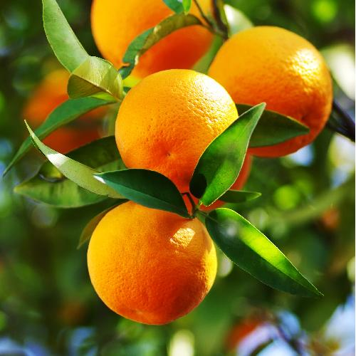

Orange

## Introduction

**R Markdown** is a powerful tool that can be used to combine text, code, and equations in a single document. **The orange tree dataset** is a classic dataset that provides 35 observations with 3 variables. It provides the age (in days) and circumference (in mm) for five type of Orange trees. We have manipulate, visualize data and built a regression model to predict the age of the orange tree based on the given circumference.

## Objective

Here, we are analyzing different aspects of orange tree by doing Exploratory,visualization and regression Data Analysis.

Frist,we are going to import the libraries

```r
library(ggplot2)
library(hrbrthemes)
library(tidyverse)
library(viridis)
```

load the data and display the head

```r
data=data.frame(Orange)
head(Orange)
```

|  | Tree | age | circumference |
| --- | --- | --- | --- |
| 1 | 1 | 118 | 30 |
| 2 | 1 | 484 | 58 |
| 3 | 1 | 664 | 87 |
| 4 | 1 | 1004 | 115 |
| 5 | 1 | 1231 | 120 |
| 6 | 1 | 1372 | 142 |

We perform some initial EDA using the DataExplorer package.

```r
library(DataExplorer)
create_report(Orange)
```

[interactive chart not shown]

check for null values

```r
is.null(data)
```

```
## [1] FALSE
```

No null values are display

```r
summary(data)
```

```
##  Tree       age         circumference
##  3:7   Min.   : 118.0   Min.   : 30.0
##  1:7   1st Qu.: 484.0   1st Qu.: 65.5
##  5:7   Median :1004.0   Median :115.0
##  2:7   Mean   : 922.1   Mean   :115.9
##  4:7   3rd Qu.:1372.0   3rd Qu.:161.5
##        Max.   :1582.0   Max.   :214.0
```

**age Column:** The smallest age in the dataset is 118.0 days. 25% of the trees have an age less than or equal to 484.0 days. 50% of the trees have an age less than or equal to 1004.0 days (also known as the second quartile). The average age of all the trees is approximately 922.1 days. 75% of the trees have an age less than or equal to 1372.0 days. The oldest tree in the dataset is 1582.0 days. **circumference Column:** The smallest circumference in the dataset is 30.0 mm. 25% of the trees have a circumference less than or equal to 65.5 mm. 50% of the trees have a circumference less than or equal to 115.0 mm (also known as the second quartile). The average circumference of all the trees is approximately 115.9 mm. 75% of the trees have a circumference less than or equal to 161.5 mm. The largest circumference in the dataset is 214.0 mm.

```r
attach(data)
cor(circumference,age)
```

```
## [1] 0.9135189
```

we have calculate the correlation between circumference and age of tree the correlation coefficient of 0.9135189 suggests a strong positive linear relationship between circumference and age , suggesting that circumference and age are highly positively associated with each other. As the circumference of the orange tree increases, its age tends to increase as well.

## Visualization

**Scatter plots**

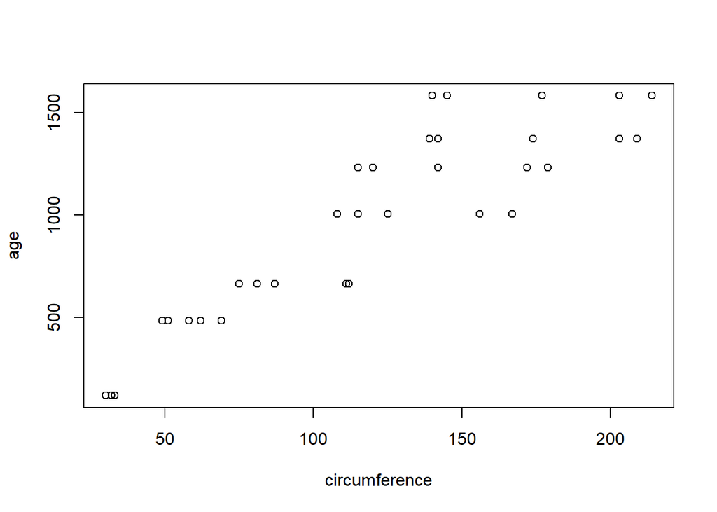

```r
plot(circumference, age)
```

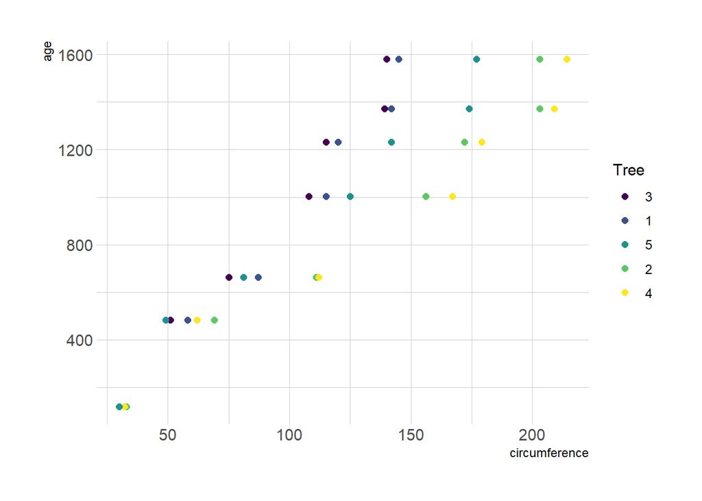

```r
ggplot(data, aes(x=circumference, y=age, color=Tree)) +
  geom_point(size=2) +
    theme_ipsum()
```

The above scatter plot summarizes the relationship of age and circumference for different types of orange trees it represent highlights the different growth patterns of orange trees of different types. Type 4 trees experience a more rapid increase in circumference, reaching the highest values among all types, while Type 3 trees exhibit slower growth and have a smaller circumference compared to the other types at the same age.

**bar plot of the tree circumference**

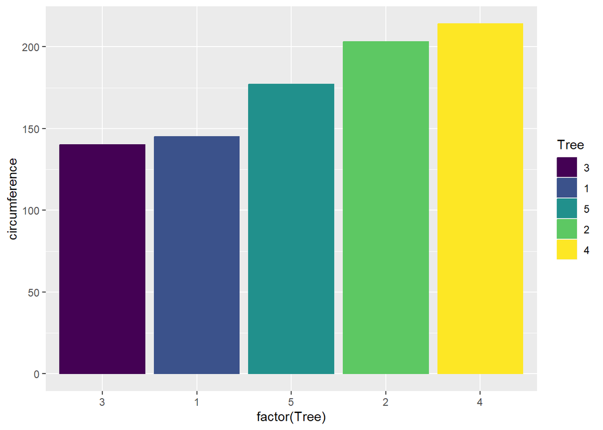

```r
ggplot(data, aes(x=factor(Tree), y=circumference,fill=Tree, color=Tree)) +
  geom_bar(stat='identity',position = 'dodge')
```

Bar plot shows that tree of type 4 has the highest circumference among all the trees. Its bar in the plot is the tallest, indicating its large size compared to the other trees. however, for a type 3 orange tree has the least circumference among all the trees. indicating its smaller size compared to the other trees.

**box plot of circumference among different type of tree**

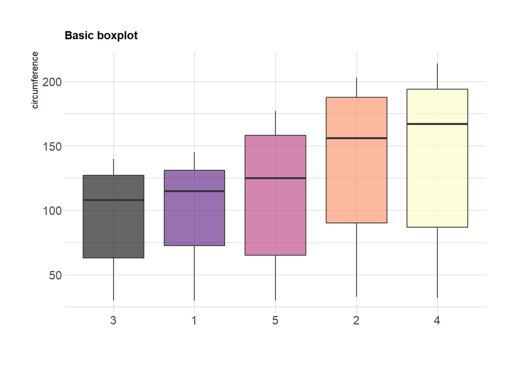

```r
data %>%
  ggplot( aes(x=Tree, y=circumference, fill=Tree)) +
  geom_boxplot() +
  scale_fill_viridis(discrete = TRUE, alpha=0.6, option="A") +
  theme_ipsum() +
  theme(
    legend.position="none",
    plot.title = element_text(size=11)
  ) +
  ggtitle("Basic boxplot") +
  xlab("")
```

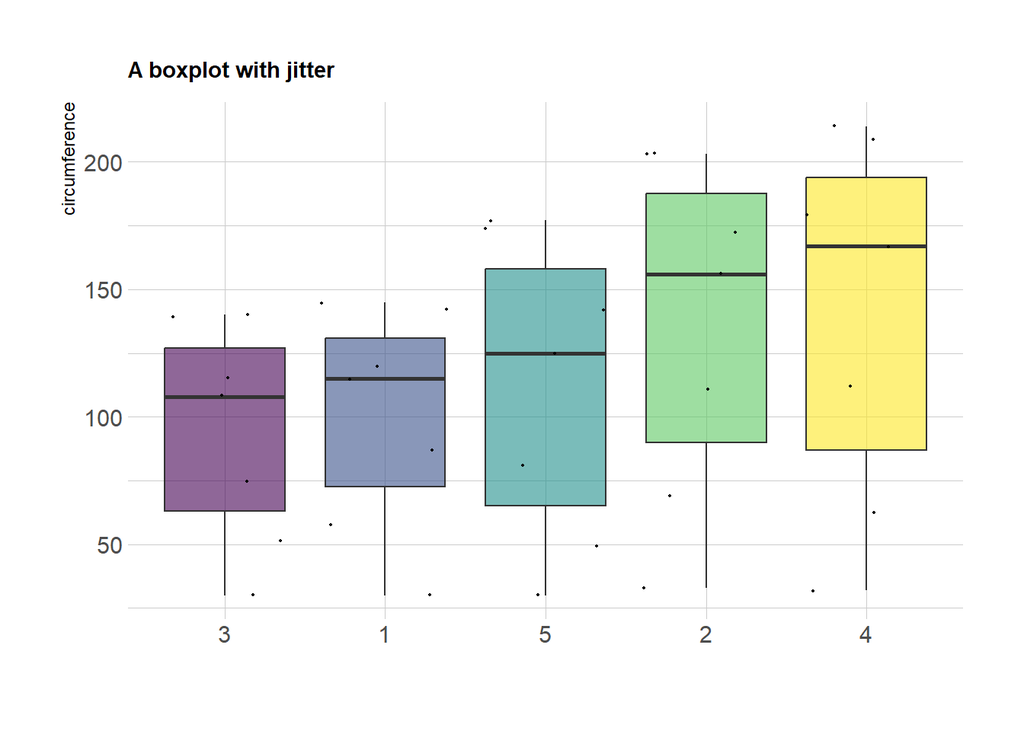

```r
data %>%
  ggplot( aes(x=Tree, y=circumference, fill=Tree)) +
  geom_boxplot() +
  scale_fill_viridis(discrete = TRUE, alpha=0.6) +
  geom_jitter(color="black", size=0.4, alpha=0.9) +
  theme_ipsum() +
  theme(
    legend.position="none",
    plot.title = element_text(size=11)
  ) +
  ggtitle("A boxplot with jitter") +
  xlab("")
```

Based on the box plot above Type 4 has the highest median circumference among all the types. The median value falls closer to the upper end of the box. Additionally, the box itself is larger, suggesting a wider range of circumference values for this type. Type 2 and 5 has a moderately large box, indicating a significant spread of circumference values. suggesting a wide range of circumference values. However, its median lower than that of Type 4. Type 1 and 3, suggesting a narrower range of circumference values. The median value falls close to the upper of the box, Type 3 has the smallest median circumference among all the types.

## Linear Regression Model

```r
model <- lm(age ~ circumference , data = Orange)
summary(model)
```

```
##
## Call:
## lm(formula = age ~ circumference, data = Orange)
##
## Residuals:
##     Min      1Q  Median      3Q     Max
## -317.88 -140.90  -17.20   96.54  471.16
##
## Coefficients:
##               Estimate Std. Error t value Pr(>|t|)
## (Intercept)    16.6036    78.1406   0.212    0.833
## circumference   7.8160     0.6059  12.900 1.93e-14 ***
## ---
## Signif. codes:  0 '***' 0.001 '**' 0.01 '*' 0.05 '.' 0.1 ' ' 1
##
## Residual standard error: 203.1 on 33 degrees of freedom
## Multiple R-squared:  0.8345, Adjusted R-squared:  0.8295
## F-statistic: 166.4 on 1 and 33 DF,  p-value: 1.931e-14
```

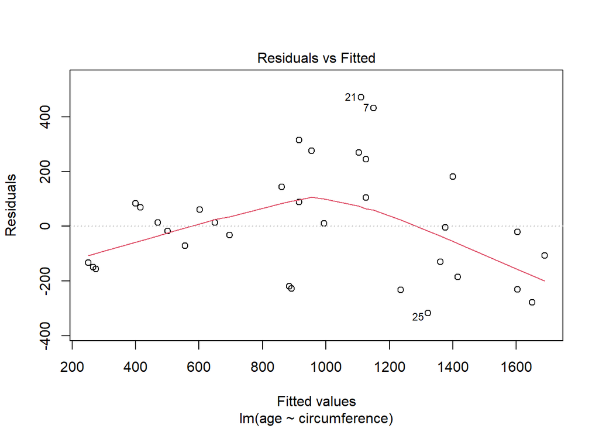

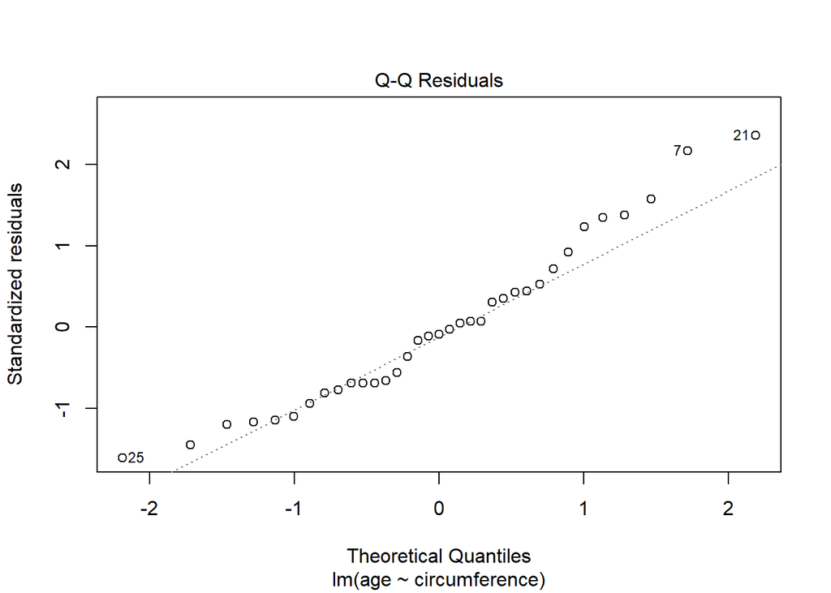

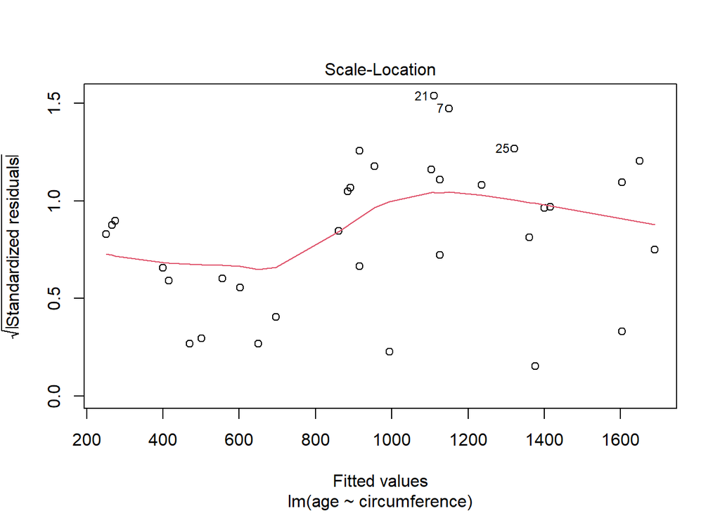

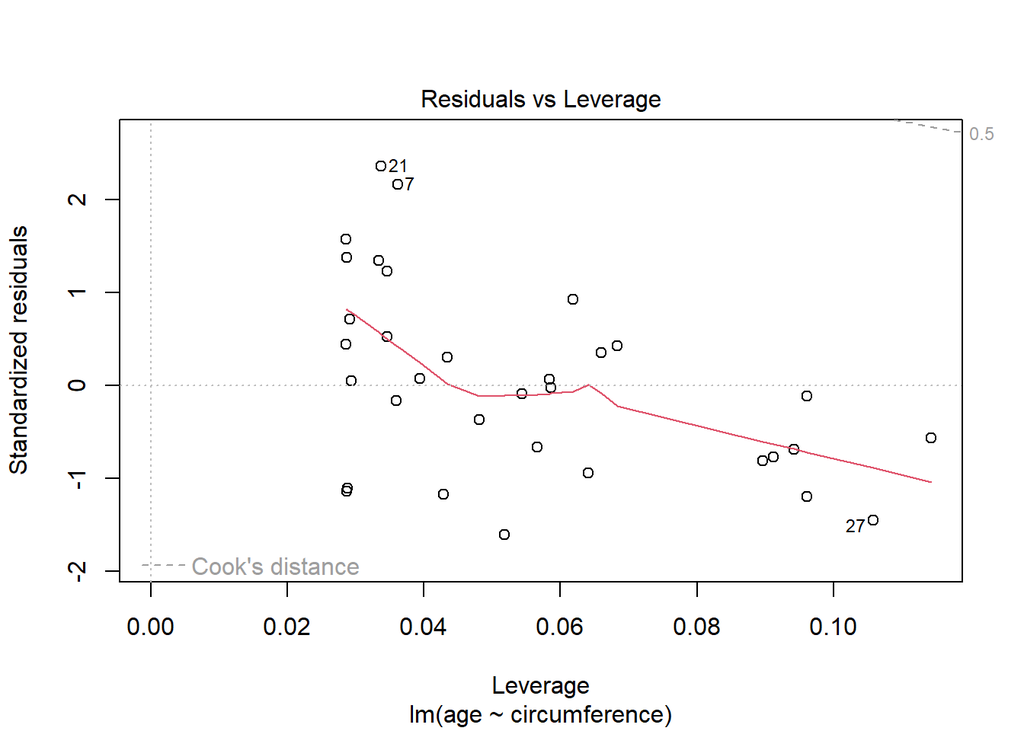

```r
plot(model)
```

## Making a Preduction

```r
circumferenceDF <- data.frame(circumference = 1243)
age <- predict(model, circumferenceDF)

# Display the age
cat("The age is:", age)
```

```
## The age is: 9731.89
```

Above code lies in its ability to make predictions based on the given (circumference) using a pre-trained linear regression model.

## conclusion

In conclusion, our project investigated five types of orange trees and identified Type 4 as the most likely to achieve the highest circumference. Additionally, we observed a positive relationship between circumference and age. The predictive model we developed holds promise for age estimation. However, we emphasize the importance of increasing the sample size to further enhance the model’s accuracy.